# pcmp: projection comparison utilities for scRNA-seq

Vincent J. Carey, stvjc at channing.harvard.edu

January 21, 2019

# 1 Introduction

Visualization of single-cell RNA-seq data is supported in many software environments and tools. pcmp was devised to address the following aims

- use Rstudio’s crosstalk to foster linked/brushable selections in multiple panels
- record manual selections of clusters with indicator variables added in the colData of the input SingleCellExperiment instance
- provide statistical information on expression patterns that distinguish selected clusters, and on expression-based sources of variation within clusters
- for nuclear sequencing applications, support introduction and interpretation of measures of relative abundance of immature transcripts

The basic interface has the following appearance:

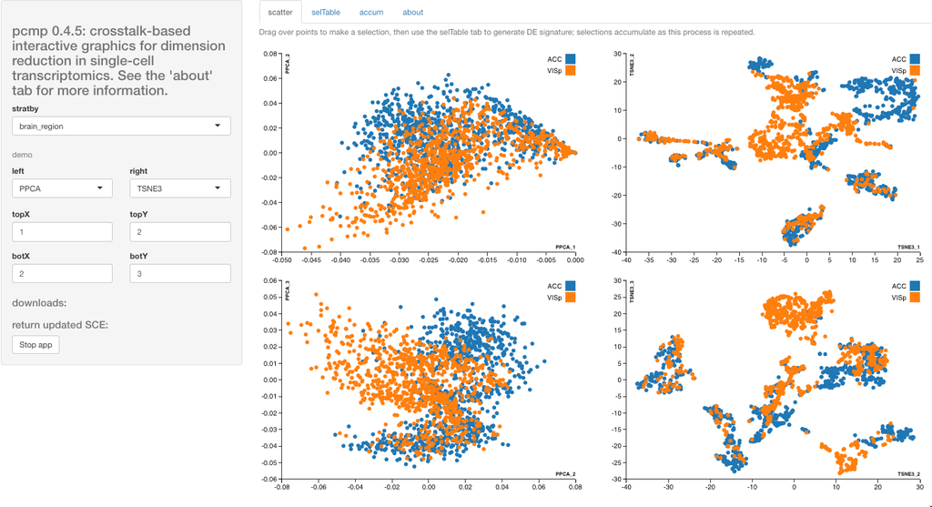

The input data are obtained from a SingleCellExperiment instance, in this case a stratified random sample of 1800 cells from the Allen Brain Atlas single-nucleus RNA-seq repositories from the ACC (anterior cingulate cortex) and VIS (primary visual cortex) brain regions.

The data are supplied in the pcmp package as the object `sce300xx`. The projections are retrieved from the reducedDims component of `sce300xx`, and **are not computed by pcmp**. Each point represents a single cell. Points are colored using palettes determined by crosstalk, and the groupings are determined by the `stratby` control, which gives access to all ‘discrete’ variables in the colData of the input SingleCellExperiment.

A couple of motivations for this app are visible in the following display, which was created by selecting a small group of mostly orange points in the center of dimensions 1,2 of the 2-dimensional t-SNE projection. You can see dashed box boundaries on the left panel. The color scheme is determined by the stratby selection. In this display color corresponds to tissue source: orange for primary visual cortex, blue for anterior cingulate cortex.

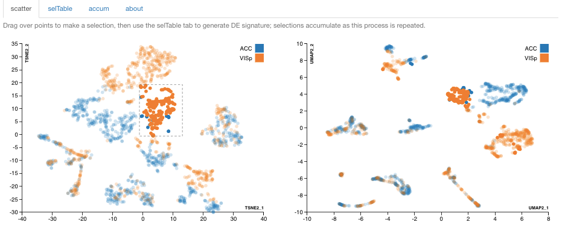

Cells are blurred in all projections if not selected.  
Most of the orange cells in the t-SNE selection are clustered together in the UMAP projection on the right, but a few are scattered to other groups that seem more remote in the UMAP view.

# 2 Installation and execution

The package can be installed using R 3.5 or above with the command

```
devtools::install_github("vjcitn/pcmp")`
```

After successful installation, use

```
library(pcmp)
pcmpApp(sce300xx)
```

to work with the sample from the Allen Brain Atlas data.

# 3 Additional features

## 3.1 Differential expression: selected cells vs. all others

A very simple approach for characterizing genes whose expression may distinguish a selected cluster is provided. We use limma on the log(assay(sce)+1) and keep the top 20 genes. **The results for a given selection are only computed if the selTable tab is selected after the selection. You will have to wait until the table appears to make a new selection.**

Here is the table that appears after the selTable tab is chosen after the selection shown in the previous display.

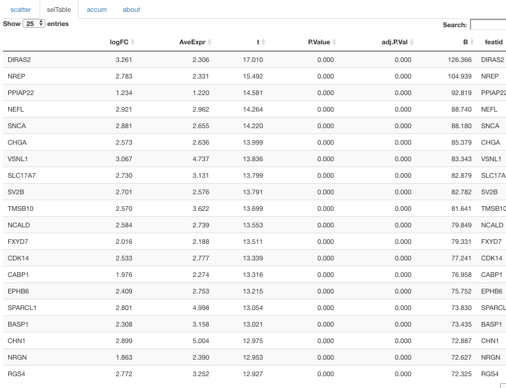

This table is stored in a special object in `.GlobalEnv` for later use.

## 3.2 Recording selections

### 3.2.1 Seeing what has been selected in the session

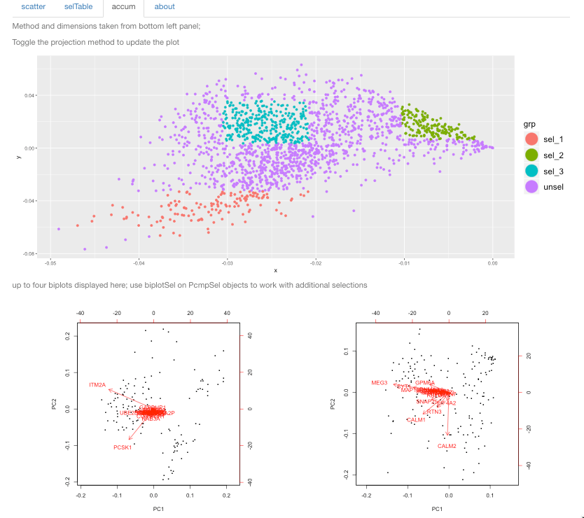

### 3.2.2 Plotting selections after a session

`pcmpApp` returns an object of class `SingleCellExperiment`. The package includes a small serialized instance with some data from `sce300xx`, called `vigAccum`.

```r
pcmp::vigAccum
```

```
## class: SingleCellExperiment
## dim: 500 900
## metadata(5): date url note params limmaTabs
## assays(1): counts
## rownames(500): OR2I1P TBCK ... OR2AJ1 CATSPER2P1
## rowData names(5): gene chromosome entrez_id gene_name
##   mouse_homologenes
## colnames(900): SM-EBKEB_S049_E1-50 SM-DD45N_S013_E1-50 ...
##   SM-GE62Q_S185_E1-50 SM-D9EQO_S96_E1-50
## colData names(45): seq_name sample_id ... sel_9 sel_10
## reducedDimNames(6): PPCA UMAP2 ... TSNE2 TSNE3
## spikeNames(0):
```

We can plot our selections in a given projection using `plotSelMap`.

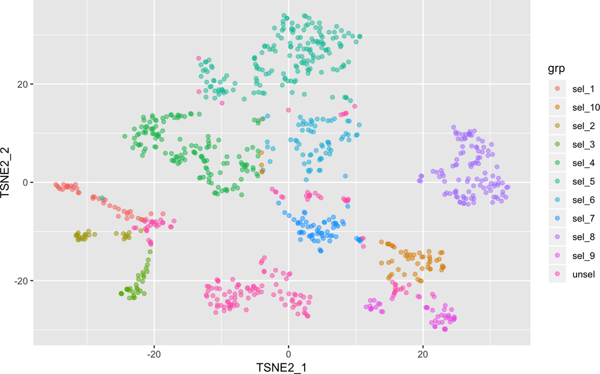

```r
plotSelMap(pcmp::vigAccum, "TSNE2", 1, 2)
```

### 3.2.3 Biplots of discriminating expression patterns

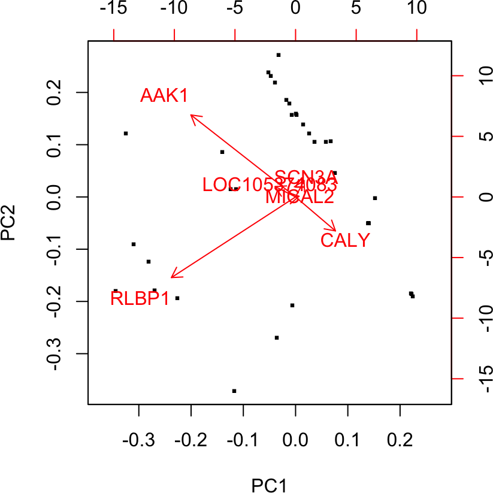

```r
biplotSel(vigAccum)
```